# Efficiency Analysis

###### B

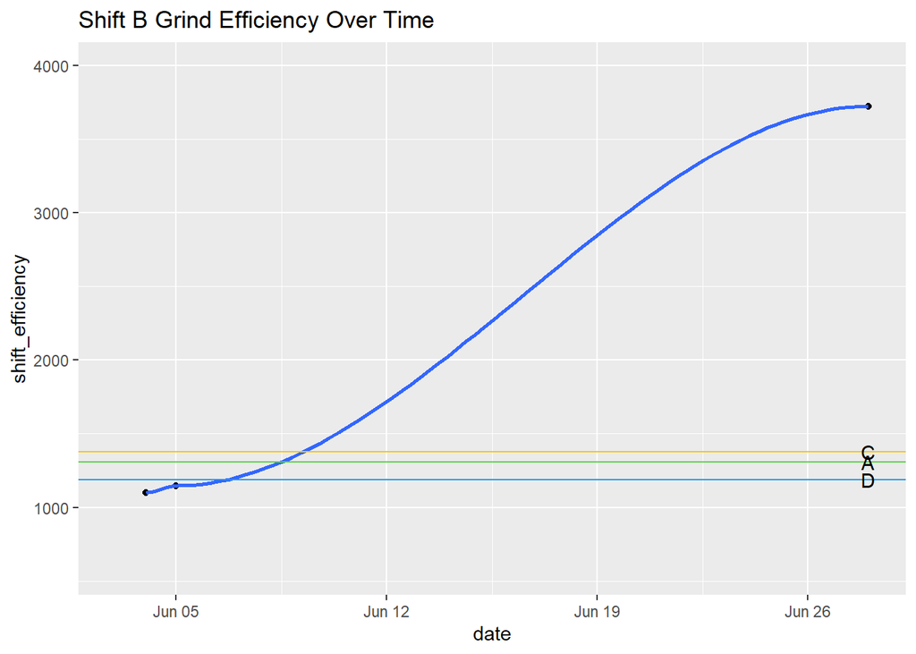

_____________________________________________________________________________________________________________________________________

###### C

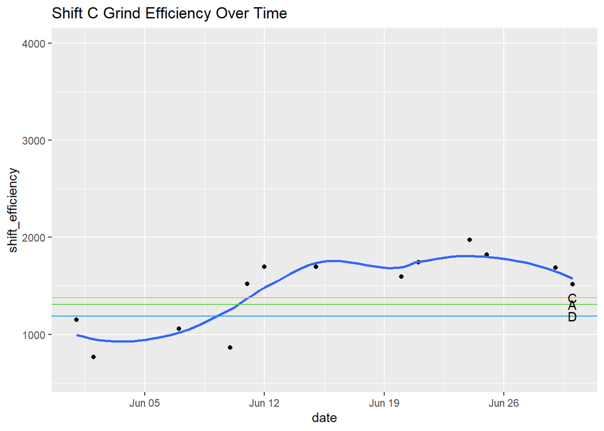

_____________________________________________________________________________________________________________________________________

###### D

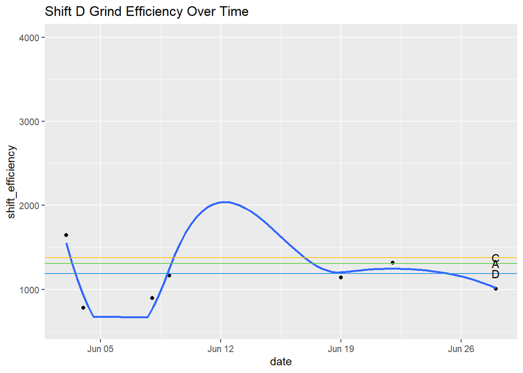

_____________________________________________________________________________________________________________________________________

#### July

July Grind Efficiecy Summary

| shift | pounds | hours | efficiency | shifts | initial | na | err |
| --- | --- | --- | --- | --- | --- | --- | --- |
| A | 36738.00 | 35.24 | 1042.51 | 5 | 7 | 2 | 0 |
| B | 35286.00 | 25.63 | 1376.75 | 5 | 9 | 4 | 0 |
| C | 26920.00 | 15.69 | 1715.74 | 3 | 6 | 3 | 0 |
| D | 24394.82 | 20.97 | 1163.32 | 3 | 10 | 6 | 1 |

- EFFICIENCY: pounds/hours
- SHIFTS: shifts included in the data
- INITIAL: shifts since 2023
- NA: shifts with missing values
- ERR: shifts with erroneous values

##### SHIFT

###### All

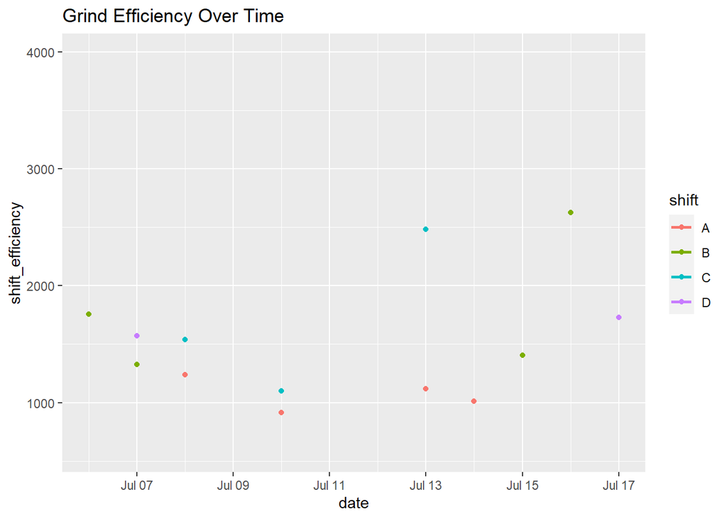

_____________________________________________________________________________________________________________________________________

###### A

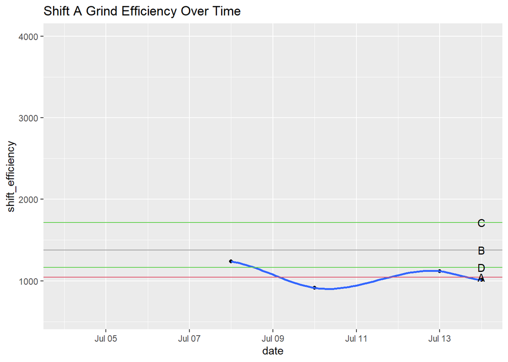

_____________________________________________________________________________________________________________________________________

###### B

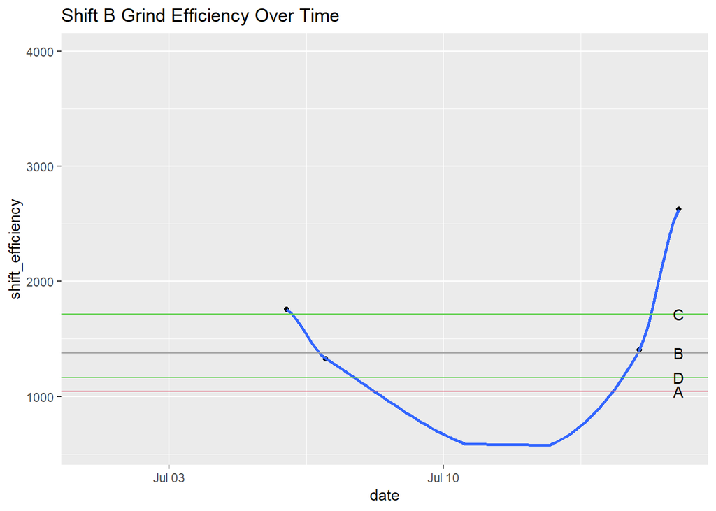

_____________________________________________________________________________________________________________________________________

###### C

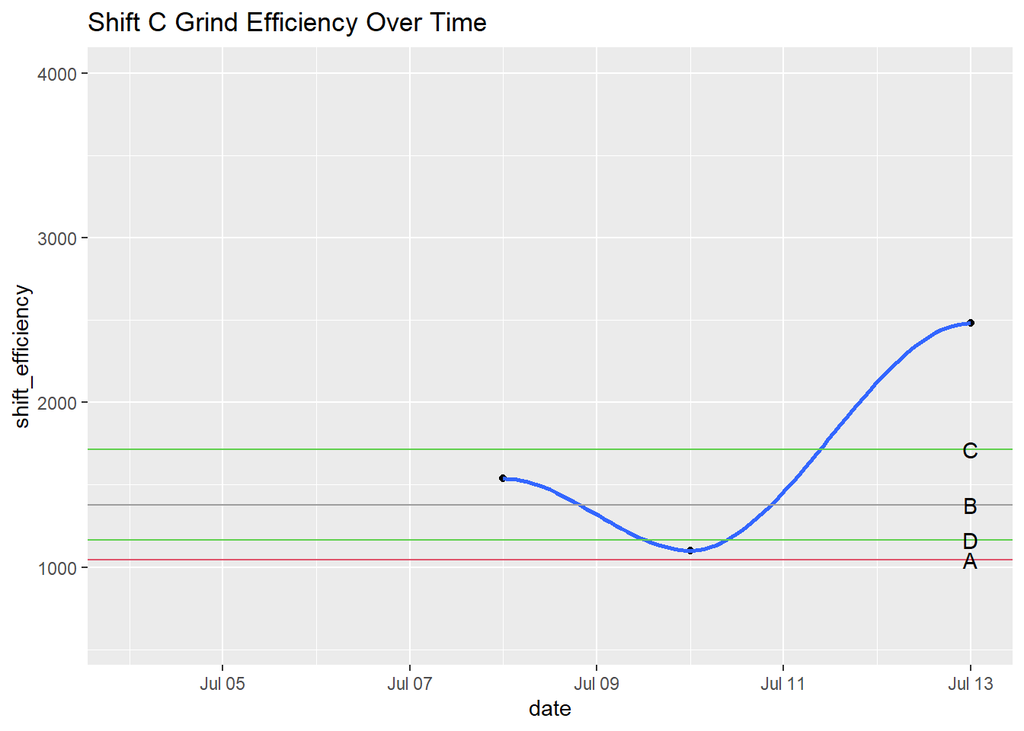

_____________________________________________________________________________________________________________________________________

###### D

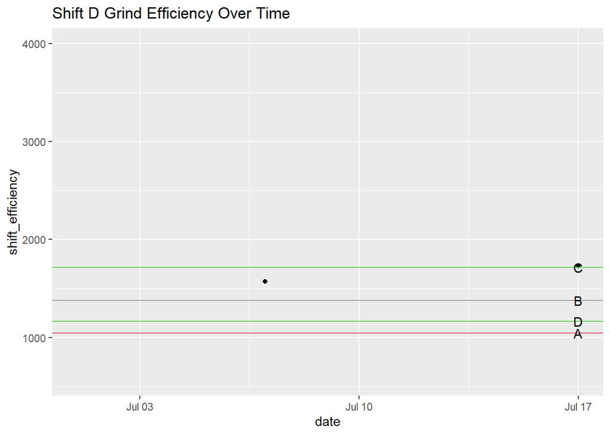

_____________________________________________________________________________________________________________________________________

## Transfer

### TIME PERIOD

#### All

All Transfer Efficiecy Summary

| shift | pounds | hours | efficiency | shifts | initial | na | err |
| --- | --- | --- | --- | --- | --- | --- | --- |
| A | 1731652 | 178.43 | 9704.94 | 66 | 98 | 30 | 2 |
| B | 2437846 | 431.10 | 5654.94 | 72 | 99 | 25 | 2 |
| C | 595137 | 76.26 | 7804.05 | 23 | 97 | 39 | 35 |
| D | 1022638 | 177.72 | 5754.21 | 38 | 100 | 46 | 16 |

- EFFICIENCY: pounds/hours
- SHIFTS: shifts included in the data
- INITIAL: shifts since 2023
- NA: shifts with missing values
- ERR: shifts with erroneous values

##### SHIFT

###### All

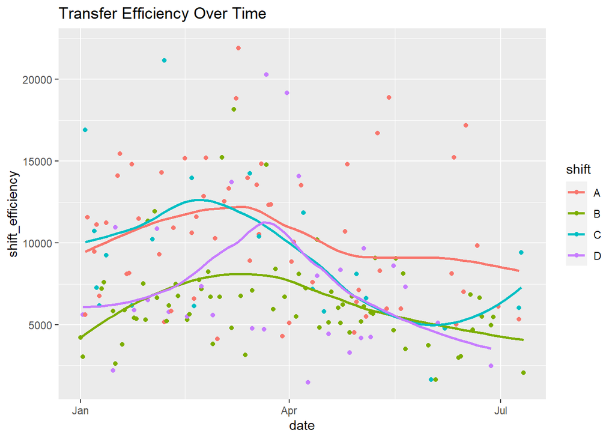

_____________________________________________________________________________________________________________________________________

###### A

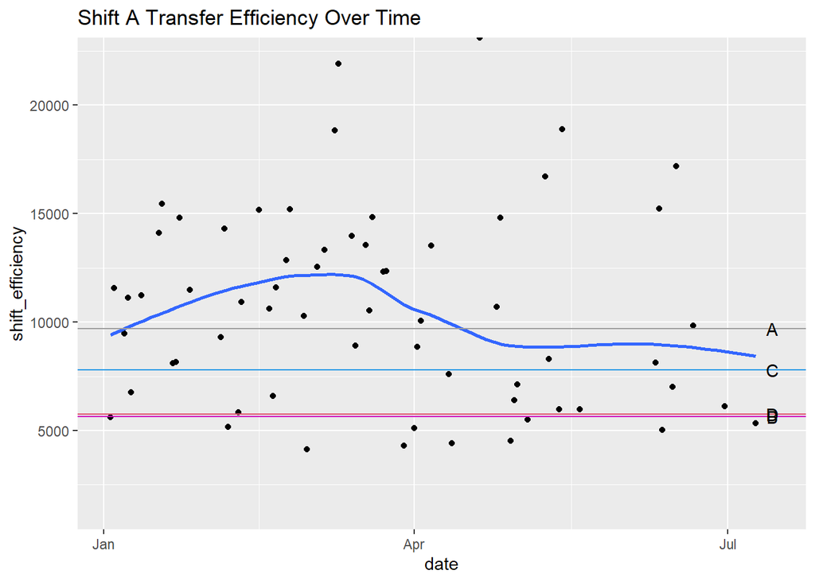

_____________________________________________________________________________________________________________________________________

###### B

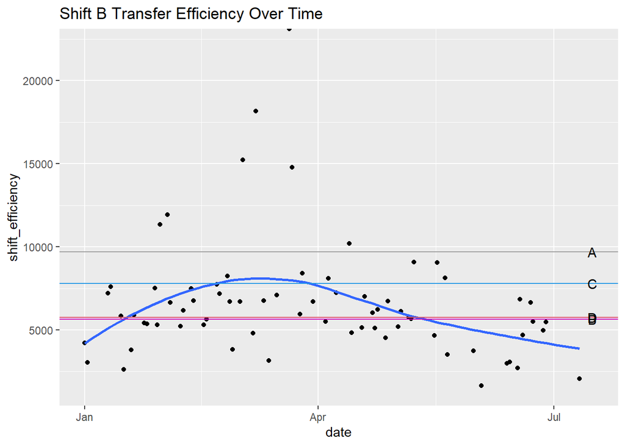

_____________________________________________________________________________________________________________________________________

###### C

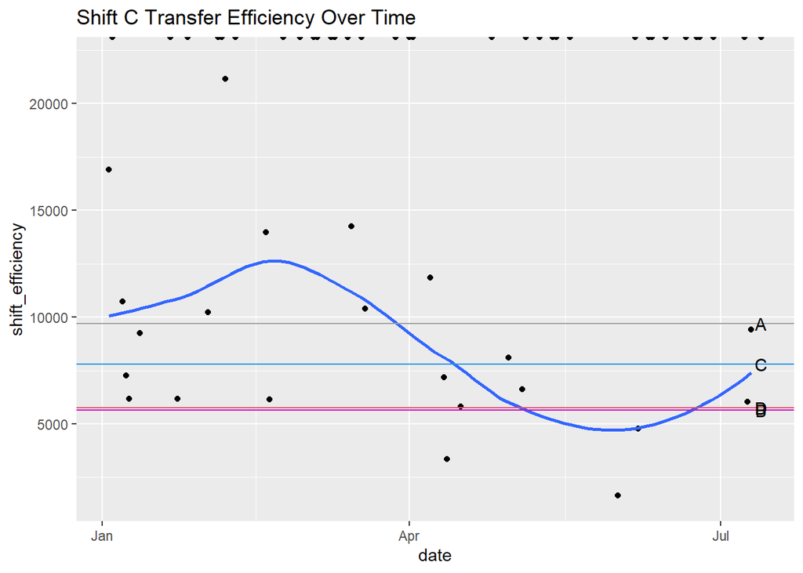

_____________________________________________________________________________________________________________________________________

###### D

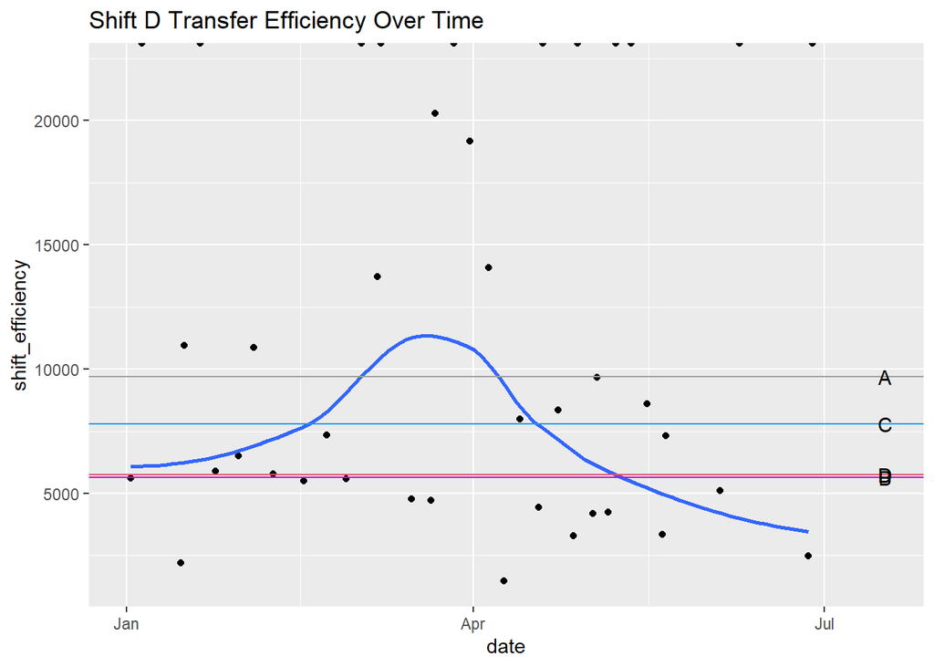

_____________________________________________________________________________________________________________________________________

#### January

January Transfer Efficiecy Summary

| shift | pounds | hours | efficiency | shifts | initial | na | err |
| --- | --- | --- | --- | --- | --- | --- | --- |
| A | 264308 | 26.04 | 10150.08 | 13 | 15 | 2 | 0 |
| B | 316075 | 62.33 | 5070.99 | 13 | 16 | 3 | 0 |
| C | 198226 | 24.62 | 8051.42 | 6 | 15 | 6 | 3 |
| D | 143443 | 22.29 | 6435.31 | 6 | 16 | 7 | 3 |

- EFFICIENCY: pounds/hours
- SHIFTS: shifts included in the data
- INITIAL: shifts since 2023
- NA: shifts with missing values
- ERR: shifts with erroneous values

##### SHIFT

###### All

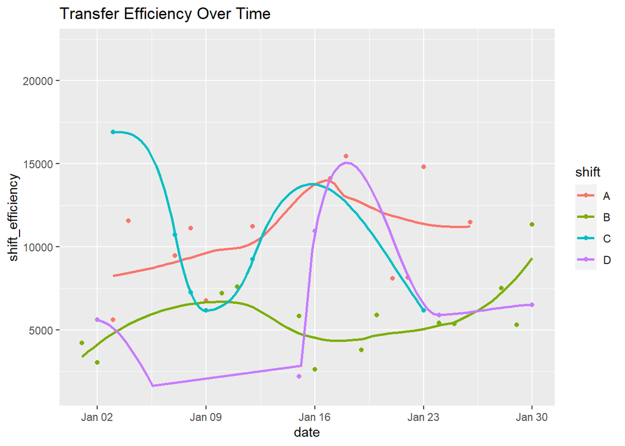

_____________________________________________________________________________________________________________________________________

###### A

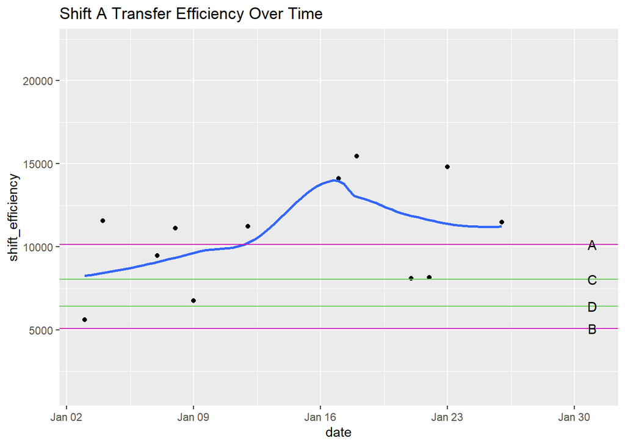

_____________________________________________________________________________________________________________________________________

###### B

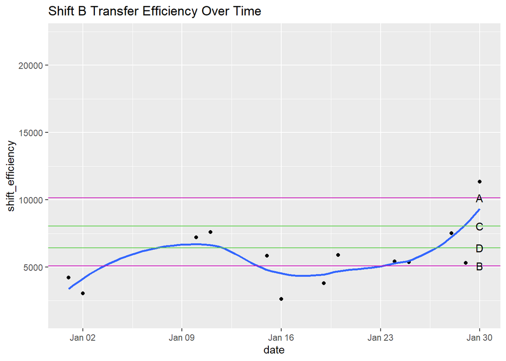

_____________________________________________________________________________________________________________________________________

###### C

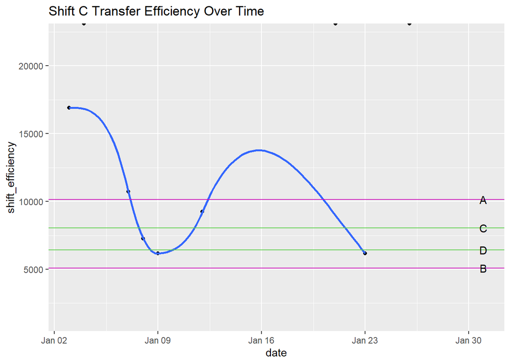

_____________________________________________________________________________________________________________________________________

###### D

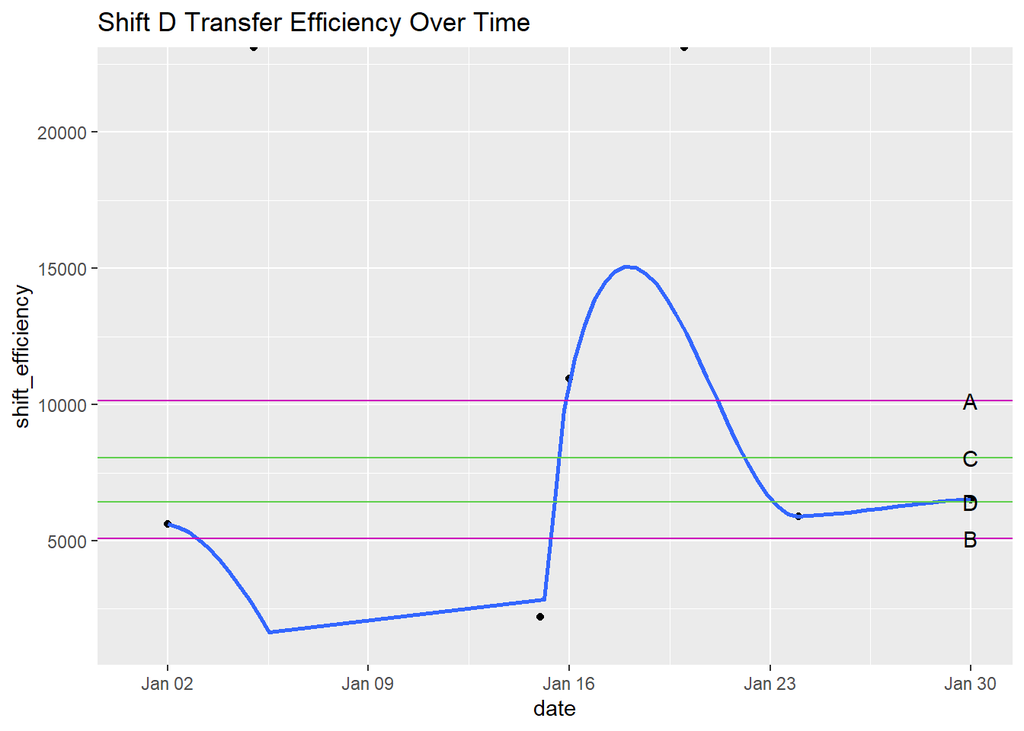

_____________________________________________________________________________________________________________________________________

#### February

February Transfer Efficiecy Summary

| shift | pounds | hours | efficiency | shifts | initial | na | err |
| --- | --- | --- | --- | --- | --- | --- | --- |
| A | 459471 | 48.61 | 9452.19 | 12 | 14 | 2 | 0 |
| B | 526508 | 83.86 | 6278.42 | 14 | 14 | 0 | 0 |
| C | 175172 | 16.11 | 10873.49 | 5 | 14 | 4 | 5 |
| D | 329978 | 41.98 | 7860.36 | 9 | 14 | 5 | 0 |

- EFFICIENCY: pounds/hours
- SHIFTS: shifts included in the data
- INITIAL: shifts since 2023
- NA: shifts with missing values
- ERR: shifts with erroneous values

##### SHIFT

###### All

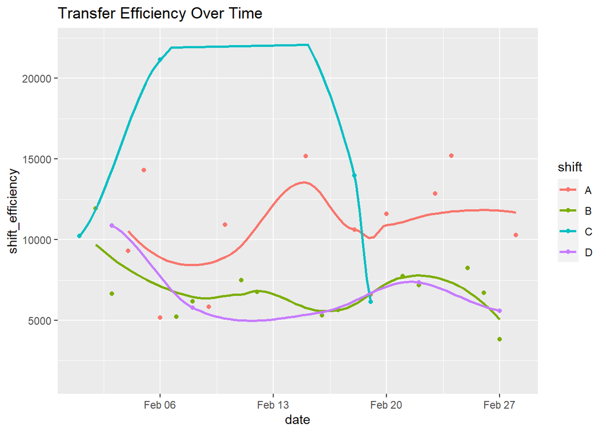

_____________________________________________________________________________________________________________________________________

###### A

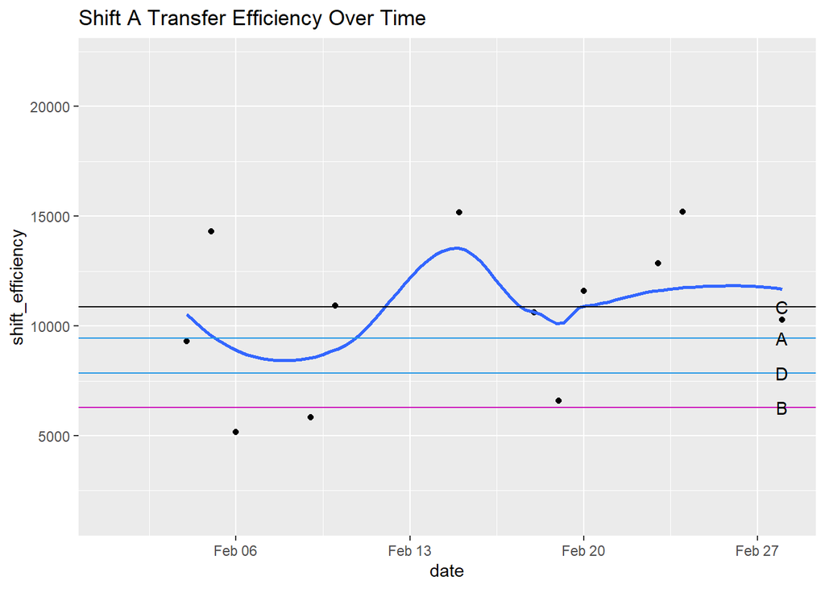

_____________________________________________________________________________________________________________________________________

###### B

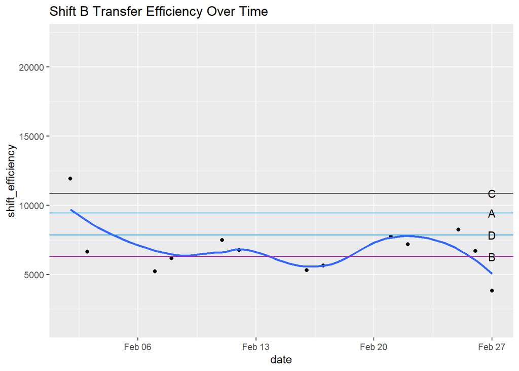

_____________________________________________________________________________________________________________________________________

###### C

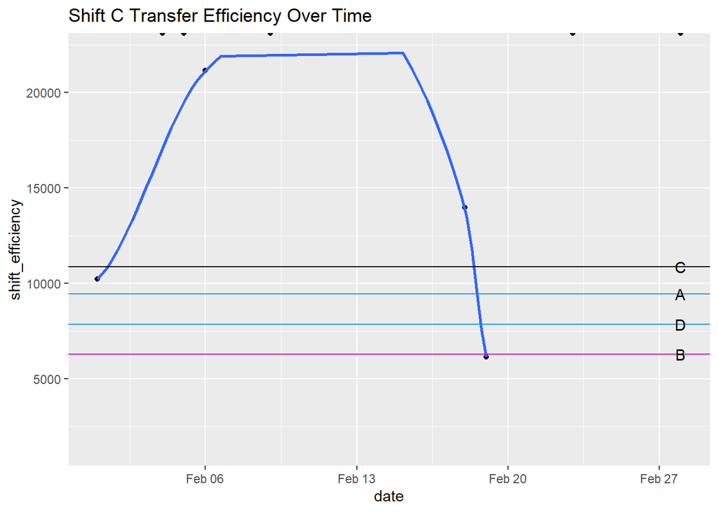

_____________________________________________________________________________________________________________________________________

###### D

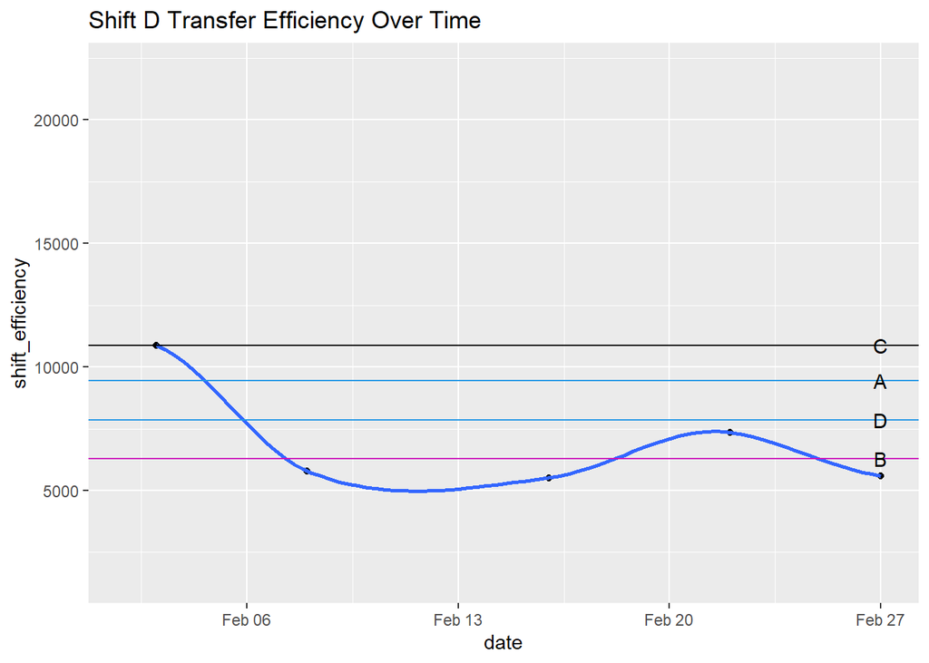

_____________________________________________________________________________________________________________________________________

#### March

March Transfer Efficiecy Summary

| shift | pounds | hours | efficiency | shifts | initial | na | err |
| --- | --- | --- | --- | --- | --- | --- | --- |
| A | 423840 | 36.92 | 11479.96 | 14 | 15 | 1 | 0 |
| B | 435505 | 66.60 | 6539.11 | 13 | 16 | 2 | 1 |
| C | 50401 | 4.08 | 12353.19 | 2 | 15 | 6 | 7 |
| D | 156410 | 22.01 | 7106.32 | 5 | 16 | 8 | 3 |

- EFFICIENCY: pounds/hours
- SHIFTS: shifts included in the data
- INITIAL: shifts since 2023
- NA: shifts with missing values
- ERR: shifts with erroneous values

##### SHIFT

###### All

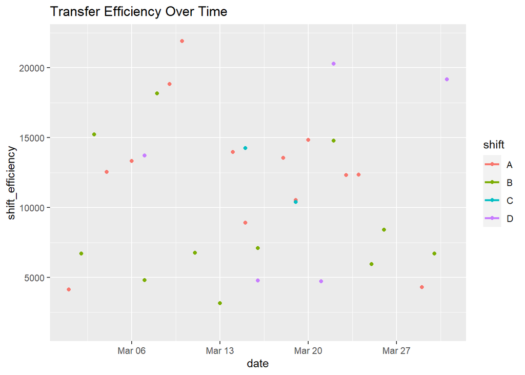

_____________________________________________________________________________________________________________________________________

###### A

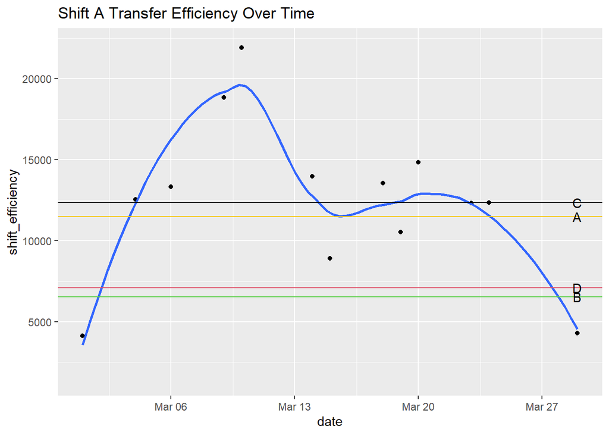

_____________________________________________________________________________________________________________________________________

###### B

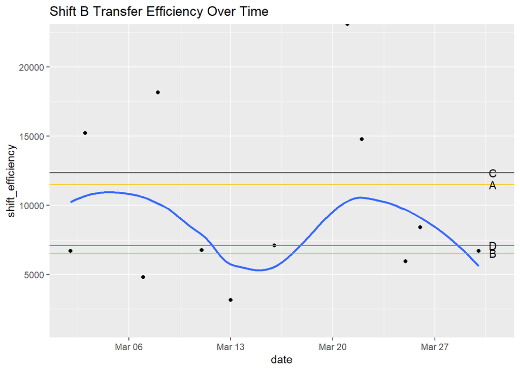

_____________________________________________________________________________________________________________________________________

###### C

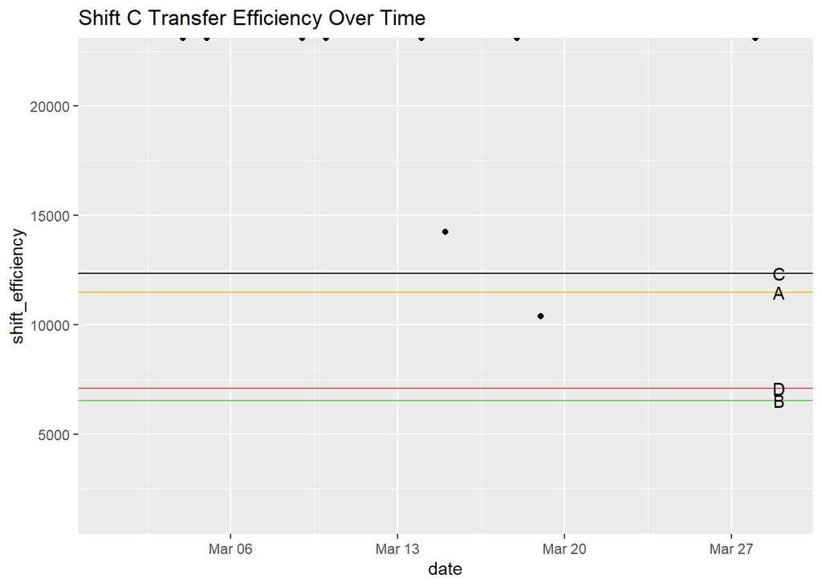

_____________________________________________________________________________________________________________________________________

###### D

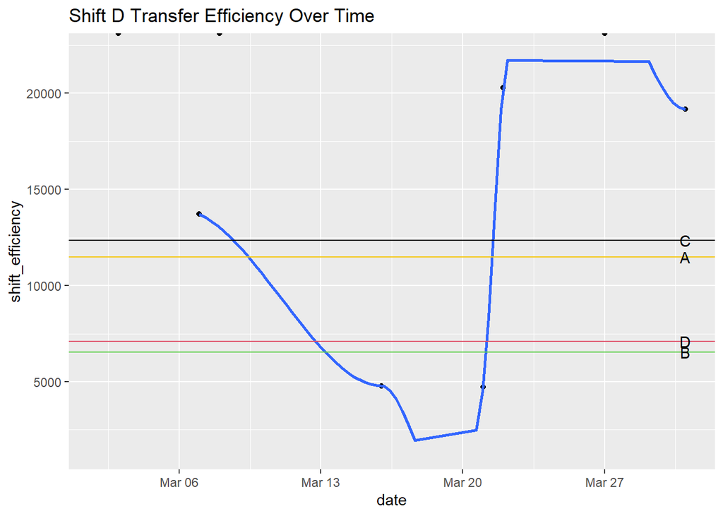

_____________________________________________________________________________________________________________________________________

#### April

April Transfer Efficiecy Summary

| shift | pounds | hours | efficiency | shifts | initial | na | err |
| --- | --- | --- | --- | --- | --- | --- | --- |
| A | 263351 | 28.74 | 9163.22 | 11 | 16 | 3 | 2 |
| B | 408227 | 65.61 | 6222.02 | 12 | 14 | 2 | 0 |
| C | 107610 | 14.81 | 7266.04 | 4 | 16 | 8 | 4 |
| D | 223122 | 39.13 | 5702.07 | 7 | 14 | 5 | 2 |

- EFFICIENCY: pounds/hours
- SHIFTS: shifts included in the data
- INITIAL: shifts since 2023
- NA: shifts with missing values
- ERR: shifts with erroneous values

##### SHIFT

###### All

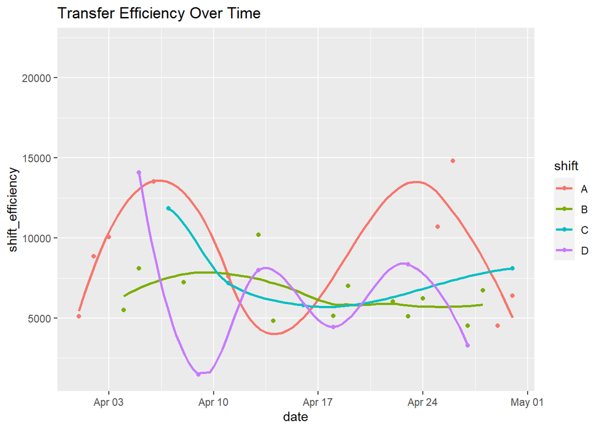

_____________________________________________________________________________________________________________________________________

###### A

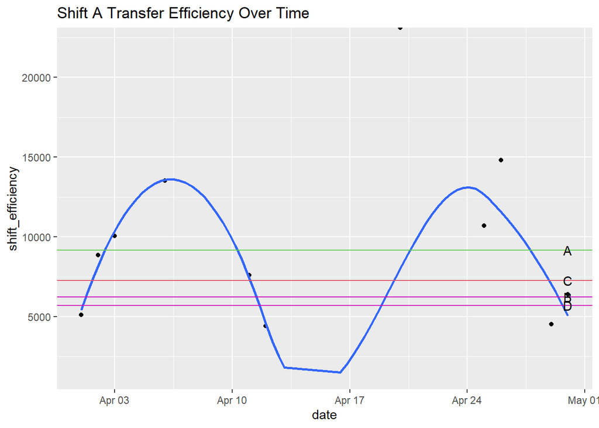

_____________________________________________________________________________________________________________________________________

###### B

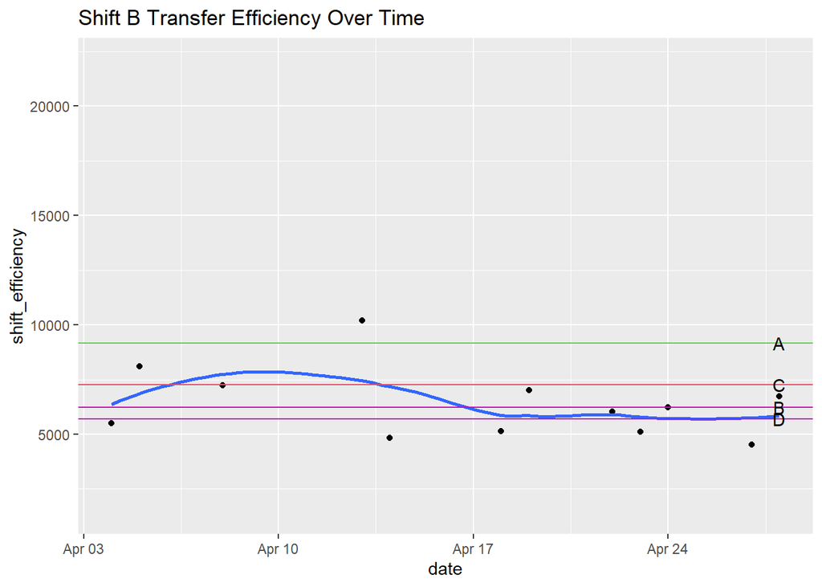

_____________________________________________________________________________________________________________________________________

###### C

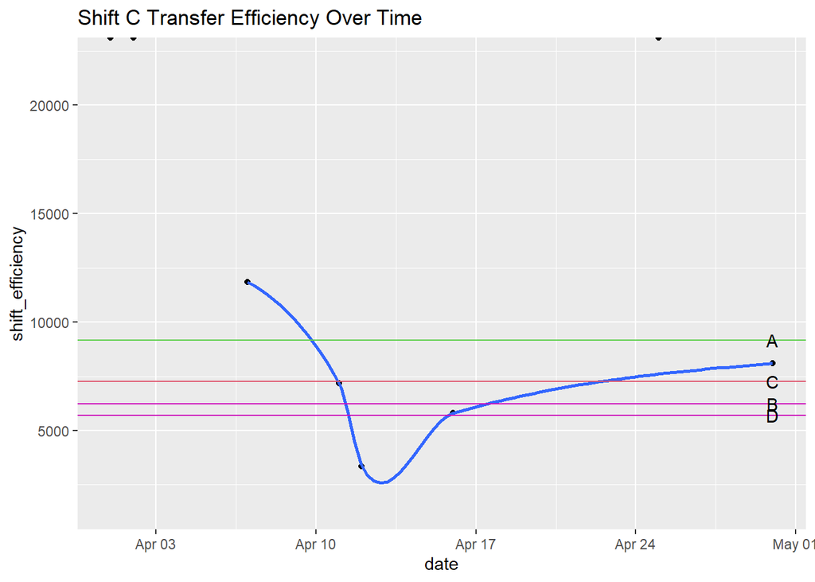

_____________________________________________________________________________________________________________________________________

###### D

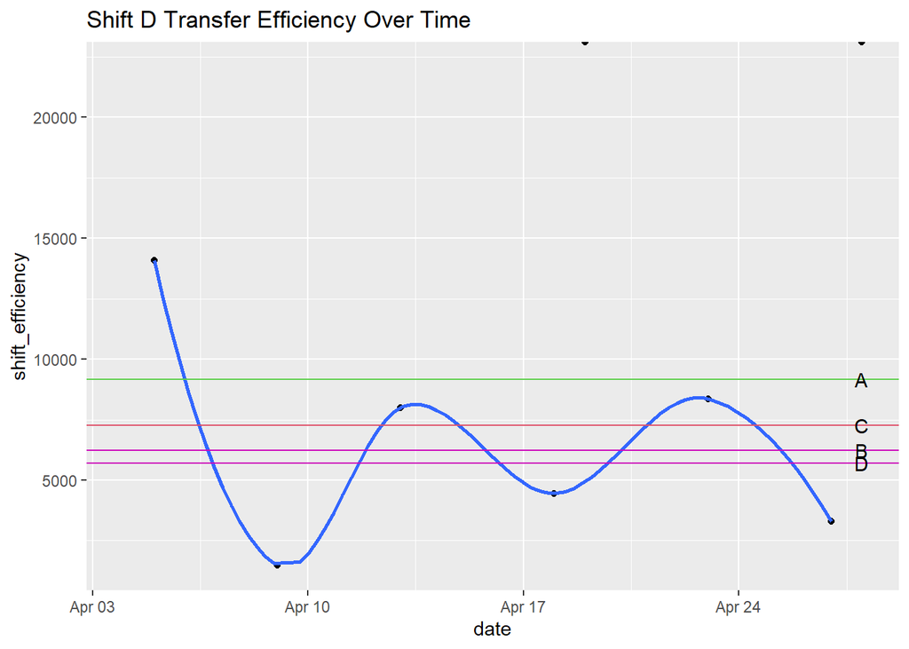

_____________________________________________________________________________________________________________________________________

#### May

May Transfer Efficiecy Summary

| shift | pounds | hours | efficiency | shifts | initial | na | err |
| --- | --- | --- | --- | --- | --- | --- | --- |
| A | 136805 | 14.19 | 9640.94 | 8 | 15 | 7 | 0 |
| B | 430022 | 79.41 | 5415.21 | 10 | 16 | 6 | 0 |
| C | 14551 | 6.84 | 2127.34 | 2 | 15 | 8 | 5 |
| D | 134816 | 30.09 | 4480.43 | 7 | 16 | 5 | 4 |

- EFFICIENCY: pounds/hours
- SHIFTS: shifts included in the data
- INITIAL: shifts since 2023
- NA: shifts with missing values
- ERR: shifts with erroneous values

##### SHIFT

###### All

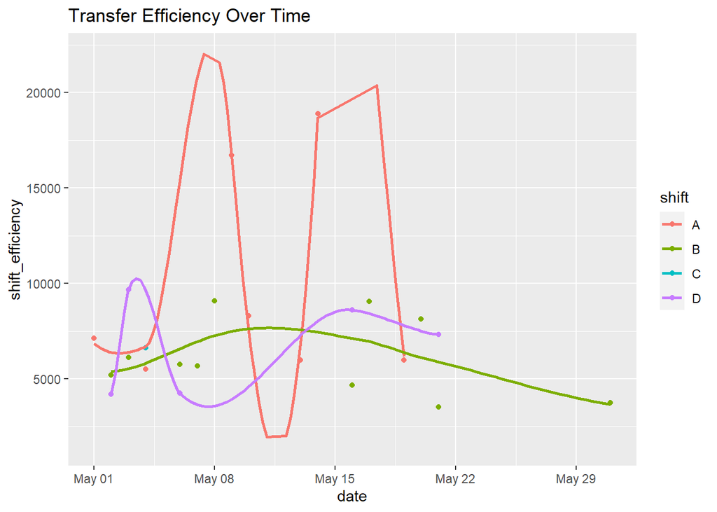

_____________________________________________________________________________________________________________________________________

###### A

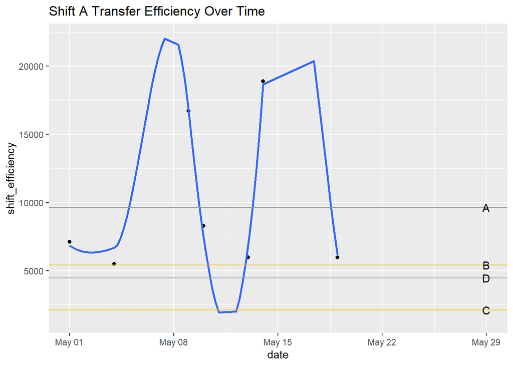

_____________________________________________________________________________________________________________________________________

###### B

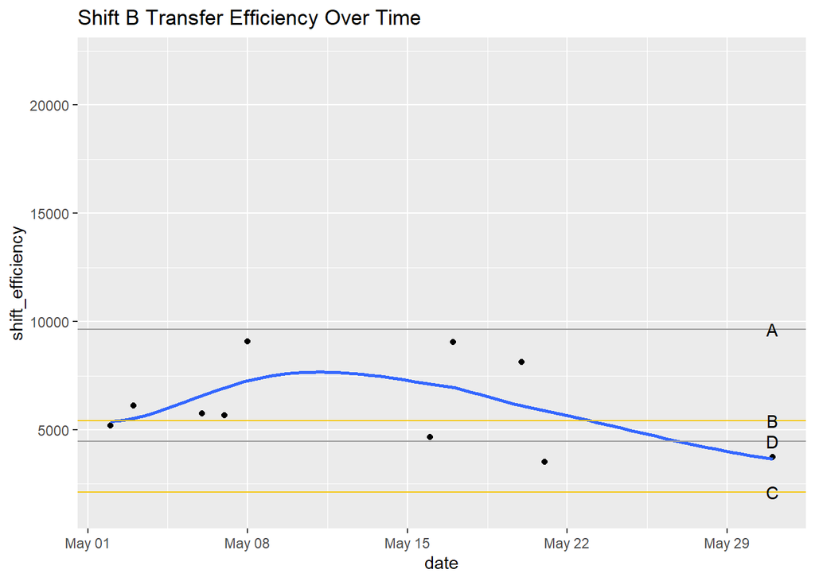

_____________________________________________________________________________________________________________________________________

###### C

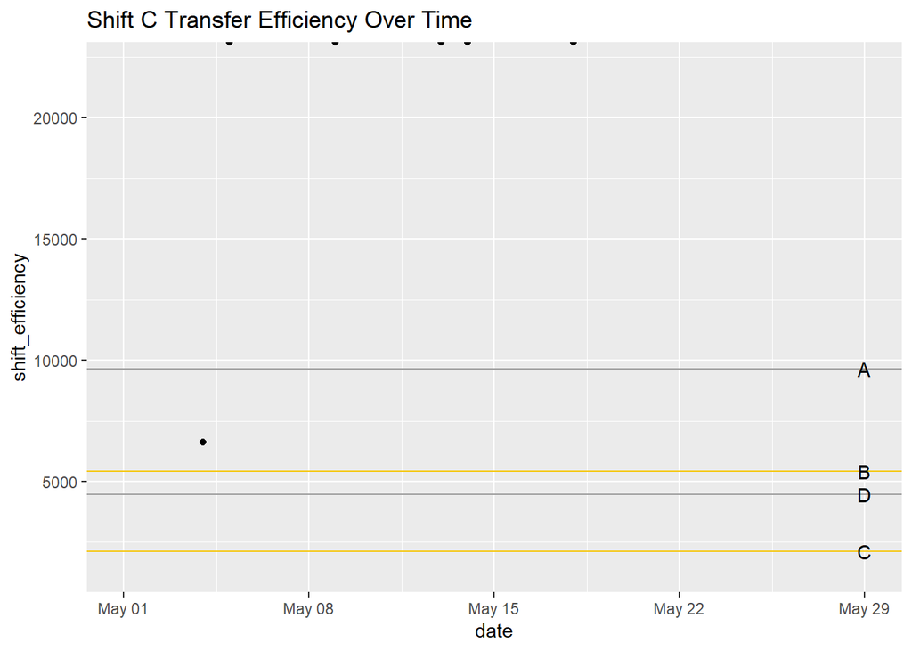

_____________________________________________________________________________________________________________________________________

###### D

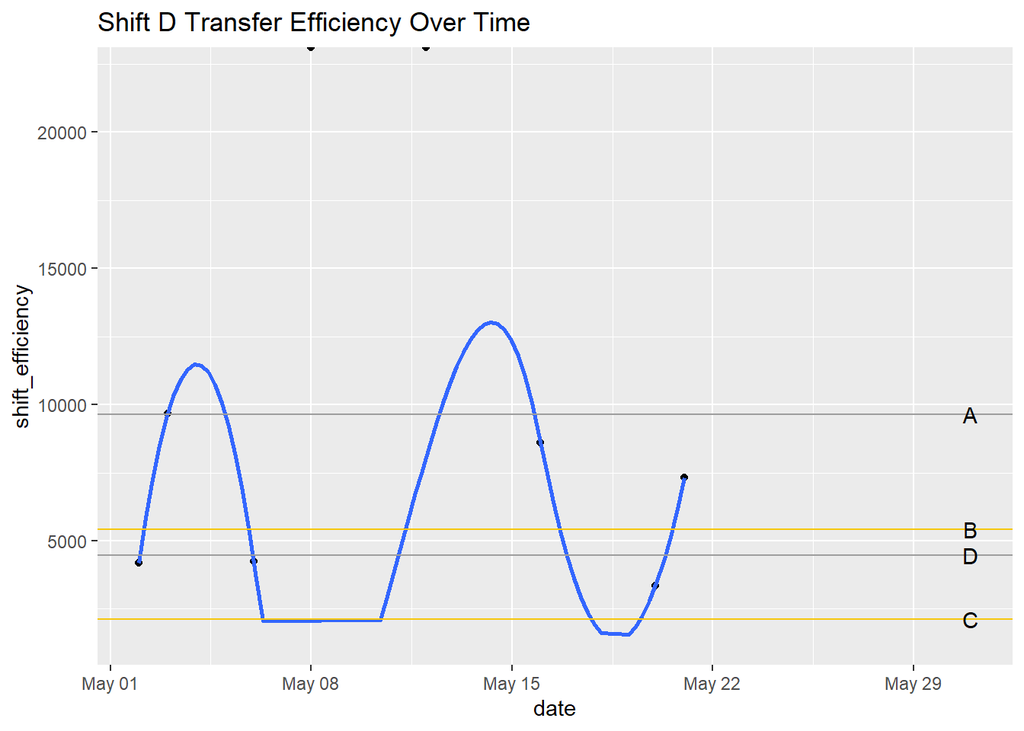

_____________________________________________________________________________________________________________________________________

#### June

June Transfer Efficiecy Summary

| shift | pounds | hours | efficiency | shifts | initial | na | err |
| --- | --- | --- | --- | --- | --- | --- | --- |
| A | 173193.00 | 21.93 | 7897.54 | 7 | 16 | 9 | 0 |
| B | 303176.00 | 64.44 | 4704.78 | 9 | 14 | 4 | 1 |
| C | 15431.00 | 5.20 | 2967.50 | 2 | 16 | 5 | 9 |
| D | 34869.39 | 22.22 | 1569.28 | 4 | 14 | 6 | 4 |

- EFFICIENCY: pounds/hours
- SHIFTS: shifts included in the data
- INITIAL: shifts since 2023
- NA: shifts with missing values
- ERR: shifts with erroneous values

##### SHIFT

###### All

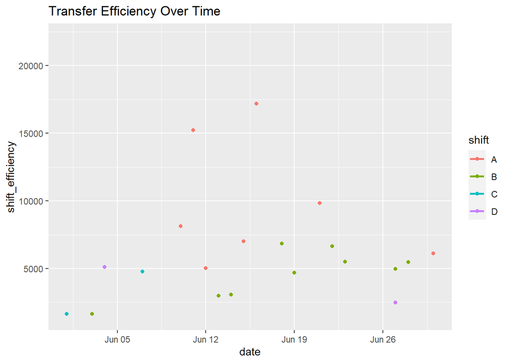

_____________________________________________________________________________________________________________________________________

###### A

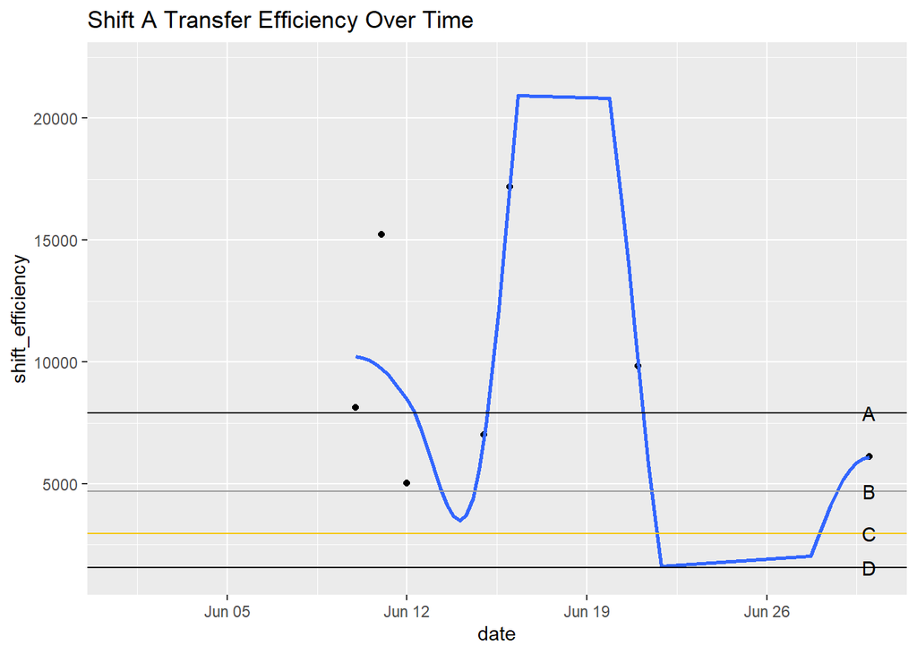

_____________________________________________________________________________________________________________________________________

###### B

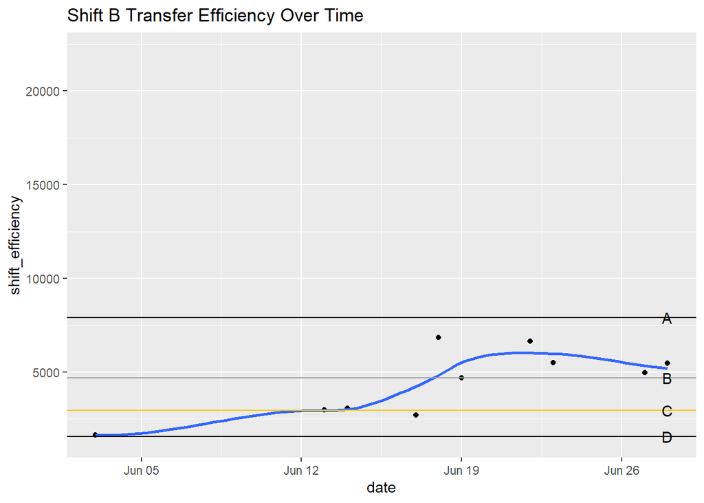

_____________________________________________________________________________________________________________________________________

###### C

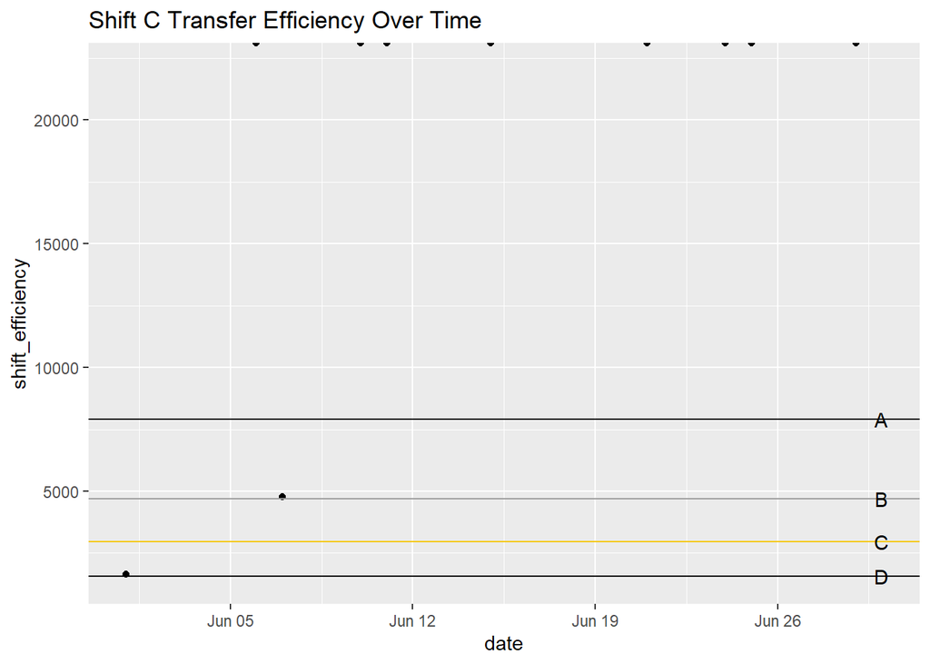

_____________________________________________________________________________________________________________________________________

###### D

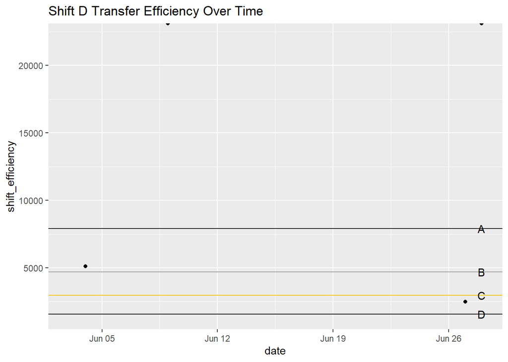

_____________________________________________________________________________________________________________________________________

#### July

July Transfer Efficiecy Summary

| shift | pounds | hours | efficiency | shifts | initial | na | err |
| --- | --- | --- | --- | --- | --- | --- | --- |
| A | 10684 | 2.00 | 5342.00 | 1 | 7 | 6 | 0 |
| B | 18333 | 8.85 | 2071.53 | 1 | 9 | 8 | 0 |
| C | 33746 | 4.60 | 7336.09 | 2 | 6 | 2 | 2 |

- EFFICIENCY: pounds/hours
- SHIFTS: shifts included in the data
- INITIAL: shifts since 2023
- NA: shifts with missing values
- ERR: shifts with erroneous values

##### SHIFT

###### All

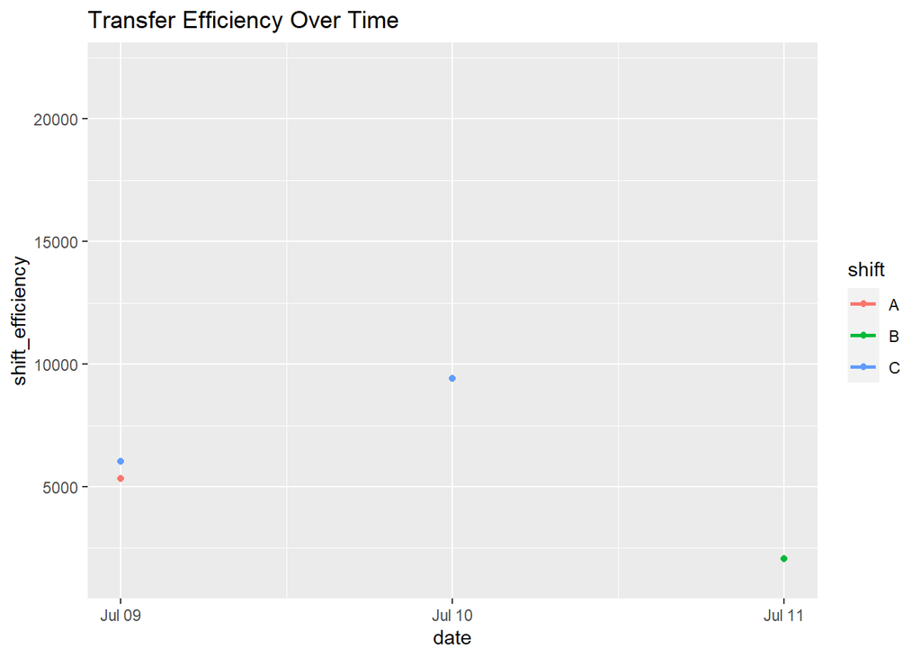

_____________________________________________________________________________________________________________________________________

###### A

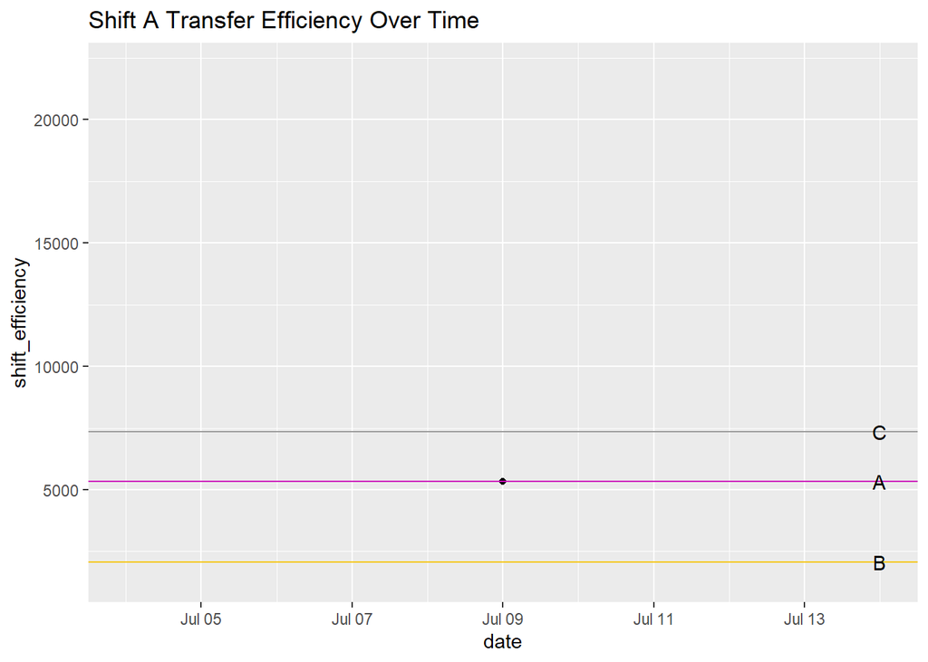

_____________________________________________________________________________________________________________________________________

###### B

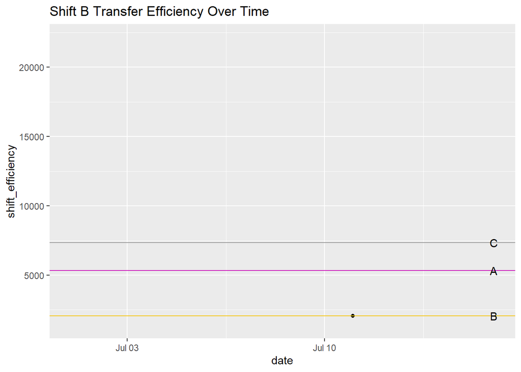

_____________________________________________________________________________________________________________________________________

###### C

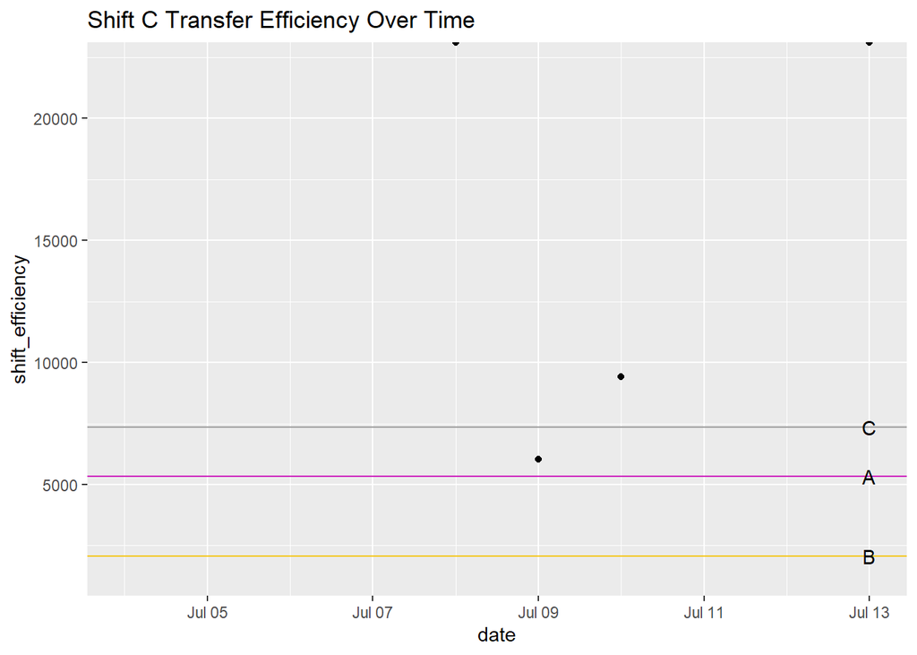

_____________________________________________________________________________________________________________________________________

###### D

[figure not shown]

_____________________________________________________________________________________________________________________________________

grinding

# Notes

### Shift A

#### Grinding

- Efficient shift that grinds approximately 1,550 pounds per hour recorded (510 hours). Of its 98 shifts since the beginning of 2023, 20 shifts contained either a missing value in the pounds or time section, so those shifts were unable to be used in the calculation and the calculation contained 78 shifts. Overall, grinding for shift A has had a fairly consistent YTD efficiency, with a recent downtrend since early may.

#### Transferring

- Very efficient shift that transfers approximately 9,700 pounds per hour recorded (178 hours). Of its 98 shifts since the beginning of 2023, 30 shifts contained either a missing value in the pounds or time section and 2 shifts had erroneous values (ex: hours > 12 or hours <= 0). These shifts were unable to be used in the calculation, so the calculation only used 66 shifts. Overall, transferring efficiency for shift A has had a fairly consistent YTD efficiency, with a recent downtrend since April.

### Shift B

#### Grinding

- Extremely efficient shift that appears to grind approximately 2,000 pounds per hour recorded (294 hours). However, it seems there could be reporting error with this group. Since the beginning of 2023, this shift has done almost 200 hours less of grinding than the next lowest shift. Also, of its 99 shifts, 42 contained either a missing value in the pounds or time section and 1 shift had erroneous values (ex: hours > 12 or hours <=0). Because these shifts are unable to be used in the calculation, only 56 shifts were used and this large loss of data could account for the lack of hours for this group. Overall, grinding efficiency for shift B started quite high at the beginning of 2023, dipped from March to May, and then recently rose agian.

### Shift C

#### Grinding

- Shift that grinds almost 1,470 pounds per hour recorded (647 hours). Of its 97 shifts since the beginning of 2023, 17 contained either a missing value in the pounds or time section and 3 shifts had erroneous values (ex: hours > 12 or hours <= 0). These shifts were unable to be used in the calculation, so the calculation contained 77 shifts. Overall, grinding efficiency for shift C has been extremely consistent, with a recent spike up since mid June.

#### Transferring

- Very efficiency shift that transfers around 7,800 pounds per hour recorded (76 hours). However, it seems there could be reporting error with this group. Since the beginning of 2023, this shift has done 100 hours less of transferring than the next lowest shift. Also in its 97 shifts, 39 contained either a missing value in the pounds or time section and 35 shifts had erroneous values (ex: hours > 12 or hours <= 0). These shifts were unable to be used in the calculation, so only 23 shifts values were used which could account for the lack of hours recorded. Overall, transferring efficiency for shift C started very high on the year, dipped during march and may, and now looks to be on the rise again.

### Shift D

#### Grinding

- Shift that grinds at the lowest efficiency of all shifts, approximately 1,460 pounds per hour recorded (490 hours). Of its 100 shifts, 33 shifts contained either a missing value in the pounds or time section and 8 shifts had erroneous values (ex: hours > 12 or hours <= 0). These shifts were unable to be used in the calculation, so only 59 shifts were used. Overall, grinding efficiency for shift D remained fairly consistent since the beginning of 2023.

#### Transferring

- Shift that grinds around 5,750 pounds per hour recorded (177 hours). However it seems there could be reporting error with this shift. In its 100 shifts, 46 shifts contained either a missing value in the pounds or time section and 16 shift had erroneous values (ex: hours > 12 or hours <= 0). These shifts were unable to be used in the calculation, so only 38 shifts were used. Overall transfer efficiency for shift D started fairly low, became very efficient in late January through March, and has recently became very inefficient throughout June.